# Laboratorio 1

Federico Daverio

# Regresión lineal y MCO

Consideramos la siguiente simulaciòn:

Creamos las observaciones con un proceso generador dado:

```r
library(tidyverse)
set.seed(1)
tb <- tibble(
  x = rnorm(10000),
  u = rnorm(10000),
  y = 5.5*x + 12*u
)
```

Efectuamos la regresiòn lineal:

```r
reg_tb <- tb %>%
  lm(y ~ x, .) %>%
  print()
```

```
##
## Call:
## lm(formula = y ~ x, data = .)
##
## Coefficients:
## (Intercept)            x
##    -0.04991      5.55690
```

```r
reg_tb$coefficients
```

```
## (Intercept)           x
## -0.04990882  5.55690164
```

Ponemos las estimaciones en un dataframe:

```r
tb <- tb %>%
  mutate(
    yhat1 = predict(lm(y ~ x, .)),
    yhat2 = 0.0732608 + 5.685033*x,
    uhat1 = residuals(lm(y ~ x, .)),
    uhat2 = y - yhat2
  )

summary(tb[-1:-3])
```

```
##      yhat1               yhat2              uhat1              uhat2
##  Min.   :-20.45096   Min.   :-20.7982   Min.   :-51.5275   Min.   :-51.5247
##  1st Qu.: -3.79189   1st Qu.: -3.7550   1st Qu.: -8.1520   1st Qu.: -8.2751
##  Median : -0.13842   Median : -0.0173   Median : -0.1727   Median : -0.3147
##  Mean   : -0.08624   Mean   :  0.0361   Mean   :  0.0000   Mean   : -0.1223
##  3rd Qu.:  3.71578   3rd Qu.:  3.9258   3rd Qu.:  7.9778   3rd Qu.:  7.8506
##  Max.   : 21.12342   Max.   : 21.7348   Max.   : 44.7176   Max.   : 44.4416
```

Ploteando:

[figure not shown]

```r
tb %>%
  lm(y ~ x, .) %>%
  ggplot(aes(x=x, y=y)) +
  ggtitle("Minimos cuadrados") +
  geom_point(size = 0.05, color = "black", alpha = 0.5) +
  geom_smooth(method = lm, color = "black") +
  annotate("text", x = -1.5, y = 30, color = "red",
           label = paste("Intercept = ", -0.0732608)) +
  annotate("text", x = 1.5, y = -30, color = "blue",
           label = paste("Slope =", 5.685033))
```

Los estimadores que obtenemos resultan similares a los reales del proceso generador de datos que en este caso conocemos.

Una vez que tenemos los estimadores podemos predecir el valor de cualquier **y** a partir de las **x**. La MCO es el mejor predictor lineal y minimiza el error de predicción minimizando la distancias verticales de las observaciones a la recta de regresión.

El coeficiente de la **x** nos permite entender el efecto marginal de unos cambios en esta:

$$\begin{align}
\Delta \widehat{y}=\widehat{\beta}_1 \Delta x
\end{align}$$

Dependendo de la transformación de nuestras variables tendremos diferentes interpretaciones de los coeficientes estimados:

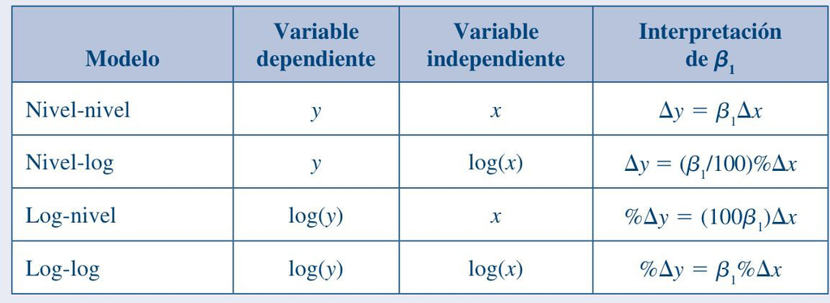

Una vez estimados $\beta_0$ y $\beta_1$ podemos utlizarlos para obtener los valores ajustados de nuestra regresión:

$$\begin{align}
\widehat{y_i}=\widehat{\beta}_0+\widehat{\beta}_1x_i
\end{align}$$

Y también los relativos residuales:

$$\begin{align}
\widehat{u_i}=y_i - \widehat{\beta}_0 - \widehat{\beta}_1 x_i
\end{align}$$

La mayoría son distintos de 0.

**¿ Que significa cuando un residual es positivo? ¿Y cuando es negativo?**

Si ploteamos los residuales obtendremos:

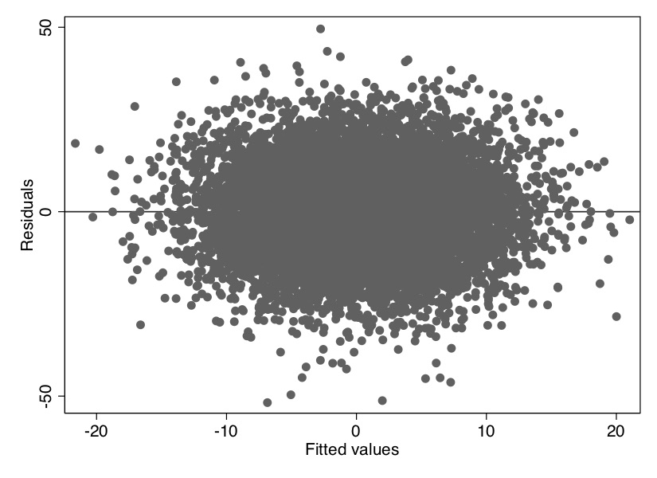

El patron esferico nos sugiere ausencia de correlación entre los residuales y los valores ajustados obtenidos.

Tenemos diferentes medidas de error para evaluar la bondad de ajuste:

$$
$$\begin{align}
SST & = \sum_{i=1}^n (y_i - \overline{y})^2
\\
SSE & = \sum_{i=1}^n (\widehat{y_i} - \overline{y})^2
\\
SSR & = \sum_{i=1}^n \widehat{u_i}^2
\end{align}$$
$$

Si dividimos SST por **n-1** obtenemos la varianza muestral de **y**.

Para poder ocupar la regresión lineal de manera eficaz y así obtener estimadores de los coeficientes poblacionales inssesgado se tienen que cumplir algunos supuestos:

1. Modelo lineral en los parametros

$y=\beta_0+\beta_1 x_1 + \dots + \beta_k x_k + \epsilon$

2. Media nula y exogeneidad estricta

Implica que el valor medio del error condicionado a las explicativas es igual al valor esperado no condicionado y vale cero. Además, la exogeneidad estricta exige que los errores del modelo no estén correlacionados con ninguna observación. $E(\epsilon_i)=0 \wedge E(\epsilon_i|x_{11}, x_{21} \dots x_{kn})=E(\epsilon_i)$

3. No multicolinealidad exacta

En la muestra ninguna de las variables explicativas es constante. No existen relaciones lineales exactas entre variables explicativas. No excluye cierta correlación (no perfecta) entre las variables. Según Gauss y Márkov, cuando un modelo tiene multicolinealidad exacta suele ser por un error del analista.

4. Homocedasticidad

La varianza del error, y por tanto de Y, es independiente de los valores de las explicativas y, además, la varianza del error constante. Matemáticamente se expresa como:

$V(\epsilon_i|X)=V(\epsilon_i|x_{11}, x_{21} \dots x_{kn})=V(\epsilon_i)=\sigma^2$

5. No autocorrelacion

Los términos de error de dos observaciones diferentes condicionadas a X están incorrelacionados. Si la muestra es aleatoria no existirá autocorrelación.

$Cov(\epsilon_i, \epsilon_h|X)=0$

## Ejemplo

Utilizamos una base ya presente en r:

```r
library(wooldridge)
```

En particular ocuparemos la CPS que es la current population surveys. Analizamos los datos presentes en la base:

```r
data("cps78_85")
names(cps78_85)
```

```
##  [1] "educ"     "south"    "nonwhite" "female"   "married"  "exper"
##  [7] "expersq"  "union"    "lwage"    "age"      "year"     "y85"
## [13] "y85fem"   "y85educ"  "y85union"
```

Podemos etiquetar las variables:

```r
library(Hmisc)
label(cps78_85$lwage) <- "Logaritmo del salario por hora"
describe(cps78_85)
```

```
## cps78_85
##
##  15  Variables      1084  Observations
## --------------------------------------------------------------------------------
## educ
##        n  missing distinct     Info     Mean      Gmd      .05      .10
##     1084        0       18    0.927    12.77    2.882        8       10
##      .25      .50      .75      .90      .95
##       12       12       14       16       18
##
## lowest :  1  2  3  4  5, highest: 14 15 16 17 18
##
## Value          1     2     3     4     5     6     7     8     9    10    11
## Frequency      1     2     1     3     2    13    13    39    27    50    50
## Proportion 0.001 0.002 0.001 0.003 0.002 0.012 0.012 0.036 0.025 0.046 0.046
##
## Value         12    13    14    15    16    17    18
## Frequency    447    74    98    38   127    39    60
## Proportion 0.412 0.068 0.090 0.035 0.117 0.036 0.055
## --------------------------------------------------------------------------------
## south
##        n  missing distinct     Info      Sum     Mean      Gmd
##     1084        0        2    0.623      319   0.2943   0.4157
##
## --------------------------------------------------------------------------------
## nonwhite
##        n  missing distinct     Info      Sum     Mean      Gmd
##     1084        0        2    0.304      124   0.1144   0.2028
##
## --------------------------------------------------------------------------------
## female
##        n  missing distinct     Info      Sum     Mean      Gmd
##     1084        0        2    0.729      452    0.417   0.4867
##
## --------------------------------------------------------------------------------
## married
##        n  missing distinct     Info      Sum     Mean      Gmd
##     1084        0        2    0.679      709   0.6541   0.4529
##
## --------------------------------------------------------------------------------
```

[output cut: 62 more lines]

```
## lowest :  0  2  3  4  5, highest: 14 15 16 17 18
##
## Value          0     2     3     4     5     6     7     8     9    10    11
## Frequency    550     1     1     1     1     3     5    15    12    17    27
## Proportion 0.507 0.001 0.001 0.001 0.001 0.003 0.005 0.014 0.011 0.016 0.025
##
## Value         12    13    14    15    16    17    18
## Frequency    219    37    56    13    71    24    31
## Proportion 0.202 0.034 0.052 0.012 0.065 0.022 0.029
## --------------------------------------------------------------------------------
## y85union
##        n  missing distinct     Info      Sum     Mean      Gmd
##     1084        0        2    0.242       96  0.08856   0.1616
##
## --------------------------------------------------------------------------------
```

Podemos renombrar los datos:

```r
library(dplyr)
names(cps78_85)
```

```
##  [1] "educ"     "south"    "nonwhite" "female"   "married"  "exper"
##  [7] "expersq"  "union"    "lwage"    "age"      "year"     "y85"
## [13] "y85fem"   "y85educ"  "y85union"
```

```r
rename(cps78_85, sur = south, año = year)
```

[output not shown]

[output cut: 2155 more lines]

### Summarise

summarise(): calcular diversas estadisticas

summarize(nombre_data_frame,formula_1, formula_2,…,formula_n)

n() - Num. de observaciones  
n_distinct(x) - Num. de obs. unicas/distintas mean() - Promedio  
median() - Mediana  
sum() - Suma  
sd() - Desv. Estandar IQR() - Rango Intercuartil mad() - Desviacion media absoluta:  
min() - Minimo max() - Maximo quantile(x, 0.25) - Cuantil first() - Primero last() - Ultimo sum([condicion logica]) - Suma de casos que cumplen condicion mean([condicion logica]) - Promedio de casos que cumplen condicion

Lo utilizamos para hacer algunos calculos:

```r
is.numeric(cps78_85$age)
```

```
## [1] TRUE
```

```r
summarise(cps78_85, min(age), max(age), mean(age), sd(age))
```

```
##   min(age) max(age) mean(age)  sd(age)
## 1       18       64  36.53967 12.20392
```

Podemos calcular estadistica descriptivas por grupos utilizando el group by():

Sin group By:

```r
summarise(cps78_85,
          prom_edad = mean(age, na.rm = TRUE),  # Promedio
          min_edad = min(age, na.rm = TRUE),    # Minimo
          max_edad = max(age, na.rm = TRUE),    # Maximo
          desv_edad = sd(age, na.rm = TRUE))    # Desviacion estandar
```

```
##   prom_edad min_edad max_edad desv_edad
## 1  36.53967       18       64  12.20392
```

Con Group By:

```r
# Agrupar los datos y guardarlos en un nuevo data frame
sexo <- group_by(cps78_85, female)

summarise(sexo,
          prom_edad = mean(age, na.rm = TRUE),  # Promedio
          min_edad = min(age, na.rm = TRUE),    # Minimo
          max_edad = max(age, na.rm = TRUE),    # Maximo
          desv_edad = sd(age, na.rm = TRUE))    # Desviacion estandar
```

```
## # A tibble: 2 x 5
##   female prom_edad min_edad max_edad desv_edad
##    <int>     <dbl>    <int>    <int>     <dbl>
## 1      0      36.7       18       64      12.2
## 2      1      36.3       18       64      12.2
```

Ahora utilizamos otra base para hacer unos calculos:

```r
library(foreign)
hogar <- as_tibble(as.data.frame(read.dta("concentradohogar.dta")))
ingreso <- as_tibble(as.data.frame(read.dta("ingresos.dta")))
vivienda <- as_tibble(as.data.frame(read.dta("viviendas.dta")))
```

Analizamos la base:

```r
View(hogar)
View(vivienda)
head(hogar)
```

```
## # A tibble: 6 x 126
##   folioviv   foliohog ubica_geo tam_loc est_socio est_dis upm     factor clase_hog
##   <chr>      <chr>    <chr>     <chr>   <chr>     <chr>   <chr>    <dbl> <chr>
## 1 0100013601 1        01001     1       3         002     0000001    175 2
## 2 0100013602 1        01001     1       3         002     0000001    175 2
## 3 0100013603 1        01001     1       3         002     0000001    175 2
## 4 0100013604 1        01001     1       3         002     0000001    175 2
## 5 0100013606 1        01001     1       3         002     0000001    175 2
## 6 0100026701 1        01001     1       3         002     0000002    189 2
## # ... with 117 more variables: sexo_jefe <chr>, edad_jefe <dbl>,
## #   educa_jefe <chr>, tot_integ <dbl>, hombres <dbl>, mujeres <dbl>,
## #   mayores <dbl>, menores <dbl>, p12_64 <dbl>, p65mas <dbl>, ocupados <dbl>,
## #   percep_ing <dbl>, perc_ocupa <dbl>, ing_cor <dbl>, ingtrab <dbl>,
## #   trabajo <dbl>, sueldos <dbl>, horas_extr <dbl>, comisiones <dbl>,
## #   aguinaldo <dbl>, indemtrab <dbl>, otra_rem <dbl>, remu_espec <dbl>,
## #   negocio <dbl>, noagrop <dbl>, industria <dbl>, comercio <dbl>, ...
```

```r
tail(hogar)
```

```
## # A tibble: 6 x 126
##   folioviv   foliohog ubica_geo tam_loc est_socio est_dis upm     factor clase_hog
##   <chr>      <chr>    <chr>     <chr>   <chr>     <chr>   <chr>    <dbl> <chr>
## 1 3260798901 1        32046     4       2         543     0008395    192 2
## 2 3260798902 1        32046     4       2         543     0008395    192 2
## 3 3260798903 1        32046     4       2         543     0008395    192 2
## 4 3260798904 1        32046     4       2         543     0008395    192 3
## 5 3260798905 1        32046     4       2         543     0008395    192 1
## 6 3260798906 1        32046     4       2         543     0008395    192 2
## # ... with 117 more variables: sexo_jefe <chr>, edad_jefe <dbl>,
## #   educa_jefe <chr>, tot_integ <dbl>, hombres <dbl>, mujeres <dbl>,
## #   mayores <dbl>, menores <dbl>, p12_64 <dbl>, p65mas <dbl>, ocupados <dbl>,
## #   percep_ing <dbl>, perc_ocupa <dbl>, ing_cor <dbl>, ingtrab <dbl>,
## #   trabajo <dbl>, sueldos <dbl>, horas_extr <dbl>, comisiones <dbl>,
## #   aguinaldo <dbl>, indemtrab <dbl>, otra_rem <dbl>, remu_espec <dbl>,
## #   negocio <dbl>, noagrop <dbl>, industria <dbl>, comercio <dbl>, ...
```

### Ejercicio 1

Calculamos el numero total de viviendas en México

**Solución**

```r
vivienda %>%
  mutate(obs = 1,
         num = obs*factor)
```

```
## # A tibble: 73,405 x 66
##    folioviv tipo_viv mat_pared mat_techos mat_pisos antiguedad antigua_ne cocina
##    <chr>    <chr>    <chr>     <chr>      <chr>          <dbl> <chr>      <chr>
##  1 0100013~ 1        8         10         3                 42 " "        1
##  2 0100013~ 1        8         10         3                 40 " "        1
##  3 0100013~ 1        8         10         3                 50 " "        1
##  4 0100013~ 1        8         10         3                 45 " "        1
##  5 0100013~ 1        8         10         3                 40 " "        1
##  6 0100026~ 1        8         10         3                  5 " "        1
##  7 0100026~ 1        8         10         3                 25 " "        1
##  8 0100026~ 1        8         10         3                 30 " "        1
##  9 0100026~ 3        8         10         2                  1 " "        2
## 10 0100027~ 1        8         10         3                 30 " "        1
## # ... with 73,395 more rows, and 58 more variables: cocina_dor <chr>,
## #   cuart_dorm <dbl>, num_cuarto <dbl>, disp_agua <chr>, dotac_agua <chr>,
## #   excusado <chr>, uso_compar <chr>, sanit_agua <chr>, biodigest <chr>,
## #   bano_comp <dbl>, bano_excus <dbl>, bano_regad <dbl>, drenaje <chr>,
## #   disp_elect <chr>, focos_inca <dbl>, focos_ahor <dbl>, combustible <chr>,
## #   estufa_chi <chr>, eli_basura <chr>, tenencia <chr>, renta <dbl>,
## #   estim_pago <dbl>, pago_viv <dbl>, pago_mesp <chr>, tipo_adqui <chr>, ...
```

Por lo tanto podemos obtener nuestras estadisticas descriptivas por la nueva variable creada:

```r
vivienda %>%
  mutate(obs = 1,
         num = obs*factor) %>%
  summarise(min(num), max(num), sum(num))
```

```
## # A tibble: 1 x 3
##   `min(num)` `max(num)` `sum(num)`
##        <dbl>      <dbl>      <dbl>
## 1          9       6727   34155615
```

Podemos hacerlo de distintas formas:

```r
vivienda %>% summarise(min(factor), max(factor), sum(factor))
```

```
## # A tibble: 1 x 3
##   `min(factor)` `max(factor)` `sum(factor)`
##           <dbl>         <dbl>         <dbl>
## 1             9          6727      34155615
```

Vamos ahora a cambiar los nombres de los estados:

```r
library(stringr)
vivienda <-
  vivienda %>%
  mutate(cve_estado = str_sub(as.character(ubica_geo), end = 2),            ##usamos ubica_geo para condicionar
         estado = case_when(cve_estado == "01" ~ "Aguascalientes",          ##podemos hacer mÃºltiples tareas
                            cve_estado == "02" ~ "Baja California",
                            cve_estado == "03" ~ "Baja California Sur",
                            cve_estado == "04" ~ "Campeche",
                            cve_estado == "05" ~ "Coahuila de Zaragoza",
                            cve_estado == "06" ~ "Colima",
                            cve_estado == "07" ~ "Chiapas",
                            cve_estado == "08" ~ "Chihuahua",
                            cve_estado == "09" ~ "Ciudad de México",
                            cve_estado == "10" ~ "Durango",
                            cve_estado == "11" ~ "Guanajuato",
                            cve_estado == "12" ~ "Guerrero",
                            cve_estado == "13" ~ "Hidalgo",
                            cve_estado == "14" ~ "Jalisco",
                            cve_estado == "15" ~ "Estado de México",
                            cve_estado == "16" ~ "Michoacán de Ocampo",
                            cve_estado == "17" ~ "Morelos",
                            cve_estado == "18" ~ "Nayarit",
                            cve_estado == "19" ~ "Nuevo León",
                            cve_estado == "20" ~ "Oaxaca",
                            cve_estado == "21" ~ "Puebla",
                            cve_estado == "22" ~ "Querétaro",
                            cve_estado == "23" ~ "Quintana Roo",
                            cve_estado == "24" ~ "San Luis Potos",
                            cve_estado == "25" ~ "Sinaloa",
                            cve_estado == "26" ~ "Sonora",
                            cve_estado == "27" ~ "Tabasco",
                            cve_estado == "28" ~ "Tamaulipas",
                            cve_estado == "29" ~ "Tlaxcala",
                            cve_estado == "30" ~ "Veracruz de Ignacio de la Llave",
                            cve_estado == "31" ~ "Yucatán",
                            cve_estado == "32" ~ "Zacatecas"))
```

Checkamos la base de nuevo:

```r
describe(vivienda)
```

```
## vivienda
##
##  66  Variables      73405  Observations
## --------------------------------------------------------------------------------
## folioviv
##        n  missing distinct
##    73405        0    73405
##
## lowest : 0100013601 0100013602 0100013603 0100013604 0100013606
## highest: 3260798902 3260798903 3260798904 3260798905 3260798906
## --------------------------------------------------------------------------------
## tipo_viv
##        n  missing distinct
##    73405        0        6
##
## lowest : & 1 2 3 4, highest: 1 2 3 4 5
##
## Value          &     1     2     3     4     5
## Frequency     51 69425  1940  1428    99   462
## Proportion 0.001 0.946 0.026 0.019 0.001 0.006
## --------------------------------------------------------------------------------
## mat_pared
##        n  missing distinct
##    73405        0        8
##
## lowest : 1 2 3 4 5, highest: 4 5 6 7 8
##
## Value          1     2     3     4     5     6     7     8
## Frequency    139   128   442   172   271  3397  6347 62509
## Proportion 0.002 0.002 0.006 0.002 0.004 0.046 0.086 0.852
## --------------------------------------------------------------------------------
## mat_techos
##        n  missing distinct
##    73405        0       10
##
## lowest : 01 02 03 04 05, highest: 06 07 08 09 10
##
## Value          1     2     3     4     5     6     7     8     9    10
## Frequency    150   616 11500  4278   216   444  3009   990  1163 51039
## Proportion 0.002 0.008 0.157 0.058 0.003 0.006 0.041 0.013 0.016 0.695
```

[output cut: 542 more lines]

```
## Proportion                                          0.01
## --------------------------------------------------------------------------------
## cve_estado
##        n  missing distinct
##    73405        0       32
##
## lowest : 01 02 03 04 05, highest: 28 29 30 31 32
## --------------------------------------------------------------------------------
## estado
##        n  missing distinct
##    73405        0       32
##
## lowest : Aguascalientes                  Baja California                 Baja California Sur             Campeche                        Chiapas
## highest: Tamaulipas                      Tlaxcala                        Veracruz de Ignacio de la Llave Yucatán                         Zacatecas
## --------------------------------------------------------------------------------
```

### Ejercicio 2

Calculamos el numero de viviendas por estados y el numero de viviendas rurales porcentualmente en cada estado.

**Solución**

```r
numero_viviendas <-
  vivienda %>%
  mutate(esvivienda = 1,
         esrural = if_else(tam_loc == 4, 1, 0), # Contamos el numero de viv. en localidades con menos de 2.5 k
         totalviviendas = esvivienda*factor,
         totalviviendas_rural = esrural*factor) %>%
  group_by(estado) %>%
  summarise(totalviviendas = sum(totalviviendas),
            totalviviendas_rural = sum(totalviviendas_rural)/sum(totalviviendas), 4)

numero_viviendas
```

```
## # A tibble: 32 x 4
##    estado               totalviviendas totalviviendas_rural   `4`
##    <chr>                         <dbl>                <dbl> <dbl>
##  1 Aguascalientes               339512              0.216       4
##  2 Baja California             1074429              0.0944      4
##  3 Baja California Sur          255062              0.151       4
##  4 Campeche                     252458              0.268       4
##  5 Chiapas                     1307648              0.487       4
##  6 Chihuahua                   1147242              0.150       4
##  7 Ciudad de México            2601456              0.00564     4
##  8 Coahuila de Zaragoza         840362              0.106       4
##  9 Colima                       228268              0.123       4
## 10 Durango                      487076              0.298       4
## # ... with 22 more rows
```

### Ejercicio 3

Promedio y mediana de numero de cuartos por vivienda por tamanio de localidad

**Solución**

```r
media_mediana<-vivienda %>%
  group_by(tam_loc) %>%
  summarise(promedio_cuartos = mean(num_cuarto, na.rm = TRUE),
            mediana_cuartos = median(num_cuarto, na.rm = TRUE),.groups='drop')
```

Tamaño localidad es una variable:

```r
print(typeof(vivienda$tam_loc))
```

```
## [1] "character"
```

```r
levels(vivienda$tam_loc)
```

El resutlado será:

```r
media_mediana
```

```
## # A tibble: 4 x 3
##   tam_loc promedio_cuartos mediana_cuartos
##   <chr>              <dbl>           <dbl>
## 1 1                   4.00               4
## 2 2                   3.68               4
## 3 3                   3.56               3
## 4 4                   3.40               3
```

Si queremos modificar el tipo de variable de tam_loc:

```r
vivienda<-vivienda %>% mutate(tam_loc=as.factor(tam_loc))
```

Ahora volviendo a correr el codigo anterior:

```r
is.factor(vivienda$tam_loc)
```

```
## [1] TRUE
```

```r
levels(vivienda$tam_loc)
```

```
## [1] "1" "2" "3" "4"
```

### Ejercicio 4

Ingreso trimestral del hogar por tamaño de localidad

**Solución**

Tenemos más que un lugar por vivienda

```r
hogar %>%
  select(folioviv, foliohog)
```

```
## # A tibble: 74,647 x 2
##    folioviv   foliohog
##    <chr>      <chr>
##  1 0100013601 1
##  2 0100013602 1
##  3 0100013603 1
##  4 0100013604 1
##  5 0100013606 1
##  6 0100026701 1
##  7 0100026703 1
##  8 0100026704 1
##  9 0100026706 1
## 10 0100027201 1
## # ... with 74,637 more rows
```

por lo tanto tendremos que crear una clave unica:

```r
hogar <-
  hogar %>%
  mutate(folioviv_hog = str_c(folioviv, as.character(foliohog)))
```

Analizamos el resultado obtenido:

```r
hogar %>%
  select(folioviv, foliohog, folioviv_hog)
```

```
## # A tibble: 74,647 x 3
##    folioviv   foliohog folioviv_hog
##    <chr>      <chr>    <chr>
##  1 0100013601 1        01000136011
##  2 0100013602 1        01000136021
##  3 0100013603 1        01000136031
##  4 0100013604 1        01000136041
##  5 0100013606 1        01000136061
##  6 0100026701 1        01000267011
##  7 0100026703 1        01000267031
##  8 0100026704 1        01000267041
##  9 0100026706 1        01000267061
## 10 0100027201 1        01000272011
## # ... with 74,637 more rows
```

Calculamos el ingreso por hogar:

```r
calculo_ingreso <-
  ingreso %>%
  mutate(folioviv_hog = str_c(folioviv, as.character(foliohog))) %>% #Mismo identificador que creamos antes
  group_by(folioviv_hog) %>% #Cálculo por hogar
  summarise(ingreso_hogar = sum(ing_tri),.groups='drop') #Sumamos las fuentes de ingreso
```

Hacemos un join para asociar el resultado obtenido a toda la listqa de hogares que habiamos identificado:

```r
hogar <-
  left_join(hogar, calculo_ingreso, by = c("folioviv_hog"))
```

Ahora podemos calcular el ingreso por localidad:

```r
ingreso_por_localidad <-
  hogar %>%
  group_by(tam_loc) %>%
  summarise(media = mean(ingreso_hogar, na.rm = TRUE),
            pc50 = median(ingreso_hogar, na.rm = TRUE),
            min = min(ingreso_hogar, na.rm = TRUE),
            max = max(ingreso_hogar, na.rm = TRUE))

ingreso_por_localidad
```

```
## # A tibble: 4 x 5
##   tam_loc  media   pc50   min       max
##   <chr>    <dbl>  <dbl> <dbl>     <dbl>
## 1 1       52856. 37746.  68.5  3916956.
## 2 2       42304. 30962. 293.   2738151.
## 3 3       35928. 26053. 293.   1626365.
## 4 4       30099. 20543.  49.2 17757845.
```

### Ejercicio 5

¿Cuántos hogares reciben más de 15% de su ingreso como beneficio del gobierno?

**Solución**

Vamos, antes que todo, a definir una dummie para identificar

```r
hogar <-
  hogar %>%
  mutate(folioviv_hog = str_c(folioviv, as.character(foliohog)),     ##indicador para hogar
         prop_gobierno = bene_gob/ing_cor,                           ##la variable de fraccion
         dmas15 = if_else(prop_gobierno > .15, 1, 0))
```

Calculamos el numero de hogares para cada localidad:

```r
hogares_loc <-
  hogar %>%
  group_by(folioviv_hog) %>%
  mutate(obs = 1,
         num = obs*factor) %>%
  ungroup() %>%
  group_by(tam_loc) %>%
  summarise(sumahogares = sum(num),.groups='drop')

hogares_loc
```

```
## # A tibble: 4 x 2
##   tam_loc sumahogares
##   <chr>         <dbl>
## 1 1          16735454
## 2 2           5107996
## 3 3           4876725
## 4 4           8024643
```

Las que si reciben más de 15% en aydua gubernamental:

```r
hogares_d <-
  hogar %>%
  filter(is.na(dmas15) != TRUE) %>%
  group_by(folioviv_hog) %>%
  mutate(obs = 1,
         num = obs*factor) %>%
  ungroup() %>%
  group_by(tam_loc, dmas15) %>%
  summarise(num = sum(num))
hogares_d
```

```
## # A tibble: 8 x 3
## # Groups:   tam_loc [4]
##   tam_loc dmas15      num
##   <chr>    <dbl>    <dbl>
## 1 1            0 16434595
## 2 1            1   297487
## 3 2            0  4882380
## 4 2            1   224555
## 5 3            0  4394684
## 6 3            1   481800
## 7 4            0  6160257
## 8 4            1  1864247
```

Construimos nuestra tabla de resumen:

```r
hogares_loc_d <- left_join(hogares_loc, hogares_d, by = "tam_loc")

hogares_loc_d <-
  hogares_loc_d %>%
  mutate(proporcion = num/sumahogares)

hogares_loc_d
```

```
## # A tibble: 8 x 5
##   tam_loc sumahogares dmas15      num proporcion
##   <chr>         <dbl>  <dbl>    <dbl>      <dbl>
## 1 1          16735454      0 16434595     0.982
## 2 1          16735454      1   297487     0.0178
## 3 2           5107996      0  4882380     0.956
## 4 2           5107996      1   224555     0.0440
## 5 3           4876725      0  4394684     0.901
## 6 3           4876725      1   481800     0.0988
## 7 4           8024643      0  6160257     0.768
## 8 4           8024643      1  1864247     0.232
```

### Ejercicio 6

Porcentaje promedio de gasto de hogares en materiales y servicios de reparacion por tamanio de localidad

**Solución**

```r
hogar <-
  hogar %>%
  mutate(prop_mater_serv = mater_serv/gasto_mon)

hogares_serv_loc <-
  hogar %>%
  group_by(tam_loc) %>%
  summarise(prom_prop_mater_serv = mean(prop_mater_serv, na.rm = TRUE))

hogares_serv_loc
```

```
## # A tibble: 4 x 2
##   tam_loc prom_prop_mater_serv
##   <chr>                  <dbl>
## 1 1                    0.00740
## 2 2                    0.00840
## 3 3                    0.0107
## 4 4                    0.0119
```

### Ejercicio 7

Regresión de porcentaje transferencia con educacióon y edad

**Solución**

```r
modelo_lineal <-lm(prop_gobierno ~ edad_jefe + educa_jefe ,hogar)
summary(modelo_lineal)
```

```
##
## Call:
## lm(formula = prop_gobierno ~ edad_jefe + educa_jefe, data = hogar)
##
## Residuals:
##      Min       1Q   Median       3Q      Max
## -0.14571 -0.03797 -0.01724  0.00309  0.86447
##
## Coefficients:
##                Estimate Std. Error t value Pr(>|t|)
## (Intercept)   8.084e-02  1.950e-03  41.463   <2e-16 ***
## edad_jefe     6.360e-04  2.332e-05  27.270   <2e-16 ***
## educa_jefe02 -1.522e-02  1.017e-02  -1.497    0.134
## educa_jefe03 -3.714e-02  1.436e-03 -25.860   <2e-16 ***
## educa_jefe04 -6.621e-02  1.463e-03 -45.270   <2e-16 ***
## educa_jefe05 -8.178e-02  2.186e-03 -37.402   <2e-16 ***
## educa_jefe06 -8.230e-02  1.445e-03 -56.955   <2e-16 ***
## educa_jefe07 -9.349e-02  2.229e-03 -41.939   <2e-16 ***
## educa_jefe08 -9.673e-02  1.637e-03 -59.088   <2e-16 ***
## educa_jefe09 -1.026e-01  2.365e-03 -43.379   <2e-16 ***
## educa_jefe10 -1.062e-01  1.676e-03 -63.347   <2e-16 ***
## educa_jefe11 -1.102e-01  2.797e-03 -39.409   <2e-16 ***
## ---
## Signif. codes:  0 '***' 0.001 '**' 0.01 '*' 0.05 '.' 0.1 ' ' 1
##
## Residual standard error: 0.08856 on 74627 degrees of freedom
##   (8 observations deleted due to missingness)
## Multiple R-squared:  0.1377, Adjusted R-squared:  0.1376
## F-statistic:  1084 on 11 and 74627 DF,  p-value: < 2.2e-16
```

# MCO Ejemplo

Importamos los datos y renombramos en español:

```r
datos<-as_tibble(wooldridge::wage1) %>%
  rename(SalarioHora=wage,
         Educación=educ,
         Experiencia=exper,
         Antiguedad=tenure,
         Género=female,
         EdoCivil=married)  %>%
  mutate(Género = recode_factor(Género, `1` = "Mujer", `0` = "Hombre"),
         EdoCivil = recode_factor(EdoCivil, `1` = "Casad@", `0` = "Solter@"))
```

Analizamos la base:

```r
View(datos)
```

Empezamos con un modelo ingenuo, para determinare el salario por hora:

```r
modelo0<-lm(SalarioHora~Género,data = datos)
```

Para obtener una tabla de resumen de esta regresión podemos hacer:

```r
summary(modelo0)
```

```
##
## Call:
## lm(formula = SalarioHora ~ Género, data = datos)
##
## Residuals:
##     Min      1Q  Median      3Q     Max
## -5.5995 -1.8495 -0.9877  1.4260 17.8805
##
## Coefficients:
##              Estimate Std. Error t value Pr(>|t|)
## (Intercept)    4.5877     0.2190  20.950  < 2e-16 ***
## GéneroHombre   2.5118     0.3034   8.279 1.04e-15 ***
## ---
## Signif. codes:  0 '***' 0.001 '**' 0.01 '*' 0.05 '.' 0.1 ' ' 1
##
## Residual standard error: 3.476 on 524 degrees of freedom
## Multiple R-squared:  0.1157, Adjusted R-squared:  0.114
## F-statistic: 68.54 on 1 and 524 DF,  p-value: 1.042e-15
```

O:

```r
library(stargazer)
stargazer(modelo0,type = "text")
```

```
##
## ===============================================
##                         Dependent variable:
##                     ---------------------------
##                             SalarioHora
## -----------------------------------------------
## GéneroHombre                 2.512***
##                               (0.303)
##
## Constant                     4.588***
##                               (0.219)
##
## -----------------------------------------------
## Observations                    526
## R2                             0.116
## Adjusted R2                    0.114
## Residual Std. Error      3.476 (df = 524)
## F Statistic           68.537*** (df = 1; 524)
## ===============================================
## Note:               *p<0.1; **p<0.05; ***p<0.01
```

Ahora añadimos un control:

```r
modelo1<-lm(SalarioHora~Género+Educación,data = datos)
summary(modelo1)
```

```
##
## Call:
## lm(formula = SalarioHora ~ Género + Educación, data = datos)
##
## Residuals:
##     Min      1Q  Median      3Q     Max
## -5.9890 -1.8702 -0.6651  1.0447 15.4998
##
## Coefficients:
##              Estimate Std. Error t value Pr(>|t|)
## (Intercept)  -1.65055    0.65232  -2.530   0.0117 *
## GéneroHombre  2.27336    0.27904   8.147 2.76e-15 ***
## Educación     0.50645    0.05039  10.051  < 2e-16 ***
## ---
## Signif. codes:  0 '***' 0.001 '**' 0.01 '*' 0.05 '.' 0.1 ' ' 1
##
## Residual standard error: 3.186 on 523 degrees of freedom
## Multiple R-squared:  0.2588, Adjusted R-squared:  0.256
## F-statistic: 91.32 on 2 and 523 DF,  p-value: < 2.2e-16
```

Podemos cambiar la categoria de referencia:

```r
datos <- datos %>%
  mutate(Género = relevel(Género, ref = "Hombre"),EdoCivil=relevel(EdoCivil,ref="Solter@"))
```

Ahora nuestor modelo será:

```r
modelo1.1<-lm(SalarioHora~Género+Educación,data = datos)
summary(modelo1.1)
```

```
##
## Call:
## lm(formula = SalarioHora ~ Género + Educación, data = datos)
##
## Residuals:
##     Min      1Q  Median      3Q     Max
## -5.9890 -1.8702 -0.6651  1.0447 15.4998
##
## Coefficients:
##             Estimate Std. Error t value Pr(>|t|)
## (Intercept)  0.62282    0.67253   0.926    0.355
## GéneroMujer -2.27336    0.27904  -8.147 2.76e-15 ***
## Educación    0.50645    0.05039  10.051  < 2e-16 ***
## ---
## Signif. codes:  0 '***' 0.001 '**' 0.01 '*' 0.05 '.' 0.1 ' ' 1
##
## Residual standard error: 3.186 on 523 degrees of freedom
## Multiple R-squared:  0.2588, Adjusted R-squared:  0.256
## F-statistic: 91.32 on 2 and 523 DF,  p-value: < 2.2e-16
```

Podemos calcular los interceptos especificos para cada genero.

```r
interceptos <- c(coef(modelo1.1)["(Intercept)"],  #intercepto de hombres
                coef(modelo1.1)["(Intercept)"] + coef(modelo1.1)["GéneroMujer"]) #intercepto de mujeres


rectas.df<- data.frame(interceptos = interceptos,
                       slopes = rep(coef(modelo1.1)["Educación"], 2),
                       Género = levels(datos$Género))
```

Y plotearlo:

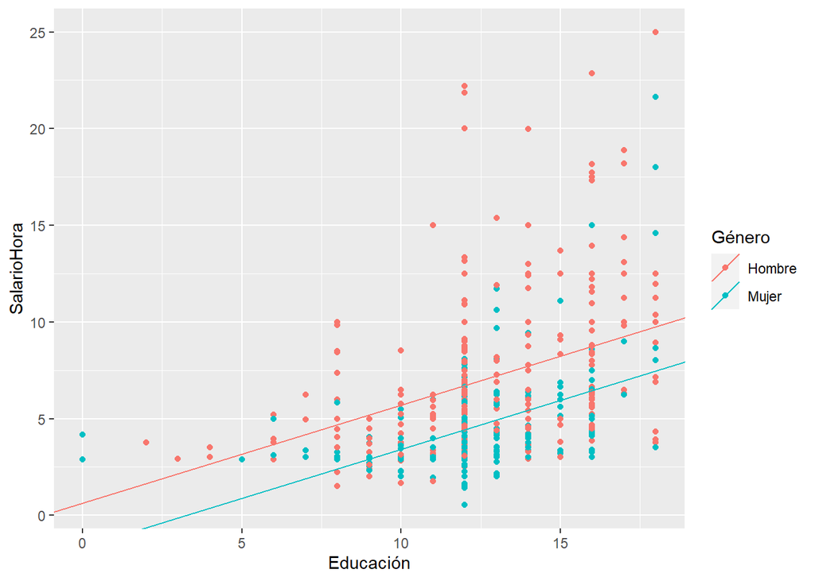

```r
qplot(x = Educación, y = SalarioHora, color = Género, data = datos) +
  geom_abline(aes(intercept = interceptos,
                  slope = slopes,
                  color = Género), data = rectas.df)
```

Siendo female= 1 si la persona es mujer y female= 0 si la persona es hombre el parámetro de “female” tiene la interpretación siguiente: es la diferencia del salario por hora entre hombres y mujeres, dada una misma cantidad de educación (y un mismo término del error,u). Determina si hay discriminación en contra de las mujeres: si, para un mismo nivel de los demás factores, parámetro de female <0, las mujeres ganan, en promedio, menos que los hombres.

Podemos interpretar el parametro female = E(wage| female,educ) - E(wage|male,educ)

```r
coef(modelo1.1)["GéneroMujer"]
```

```
## GéneroMujer
##   -2.273362
```

```r
  #intercepto Hombres
  interceptos[1]
```

```
## (Intercept)
##   0.6228168
```

```r
  #intercepto Mujeres
  interceptos[2]
```

```
## (Intercept)
##   -1.650545
```

Podemos efectuar una regresión sin intercepto:

```r
library(kableExtra)
library(xtable)
modelo1.2<-lm(SalarioHora~Género+Educación-1,data = datos)
salida.modelo1.2<- data.frame(xtable(summary(modelo1.2))) #Resumen del modelo 1.7
kable(salida.modelo1.2, caption="Ecuación de Salario con Género y Educación, sin intercepto")
```

Ecuación de Salario con Género y Educación, sin intercepto

|  | Estimate | Std..Error | t.value | Pr…t.. |
| --- | --- | --- | --- | --- |
| GéneroHombre | 0.6228168 | 0.6725334 | 0.9260756 | 0.3548338 |
| GéneroMujer | -1.6505451 | 0.6523170 | -2.5302806 | 0.0116894 |
| Educación | 0.5064521 | 0.0503906 | 10.0505201 | 0.0000000 |

En este caso como se interpretan los coeficientes?

Los interceptos serán dados por el parametro asociado al genero.

Podemos añadir más covariables (X).

```r
modelo1.3<-lm(SalarioHora~Género+Educación+Experiencia+Antiguedad,data = datos)

salida.modelo1.3<- data.frame(xtable(summary(modelo1.3))) #Resumen del modelo 1.7
kable(salida.modelo1.3, caption="Modelo de regresión múltiple para el Salario por hora")
```

Modelo de regresión múltiple para el Salario por hora

|  | Estimate | Std..Error | t.value | Pr…t.. |
| --- | --- | --- | --- | --- |
| (Intercept) | -1.5679387 | 0.7245511 | -2.164014 | 0.0309170 |
| GéneroMujer | -1.8108522 | 0.2648252 | -6.837915 | 0.0000000 |
| Educación | 0.5715048 | 0.0493373 | 11.583621 | 0.0000000 |
| Experiencia | 0.0253959 | 0.0115694 | 2.195083 | 0.0285981 |
| Antiguedad | 0.1410051 | 0.0211617 | 6.663225 | 0.0000000 |

Podemos utilziar más de una variable dicotomica en una regresión:

```r
modelo1.4<-lm(log(SalarioHora)~Género+Educación+EdoCivil+
                   Experiencia+I(Experiencia^2)+Antiguedad+I(Antiguedad^2),data = datos)
```

El resultado arrojado será:

```r
salida.modelo1.4<- data.frame(xtable(summary(modelo1.4))) #Resumen del modelo 1.7
kable(salida.modelo1.4, caption="Modelo con dos variables dicotómicas")
```

Modelo con dos variables dicotómicas

|  | Estimate | Std..Error | t.value | Pr…t.. |
| --- | --- | --- | --- | --- |
| (Intercept) | 0.4177837 | 0.0988662 | 4.225749 | 0.0000281 |
| GéneroMujer | -0.2901837 | 0.0361121 | -8.035646 | 0.0000000 |
| Educación | 0.0791547 | 0.0068003 | 11.639885 | 0.0000000 |
| EdoCivilCasad@ | 0.0529219 | 0.0407561 | 1.298503 | 0.1946922 |
| Experiencia | 0.0269535 | 0.0053258 | 5.060949 | 0.0000006 |
| I(Experiencia^2) | -0.0005399 | 0.0001122 | -4.813500 | 0.0000019 |
| Antiguedad | 0.0312962 | 0.0068482 | 4.569988 | 0.0000061 |
| I(Antiguedad^2) | -0.0005744 | 0.0002347 | -2.447533 | 0.0147147 |

Una limitación importante de este modelo es que se supone que la prima de casado es la misma para hombres que para mujeres; esto se soluciona en el siguitnte modelo

Creamos una variable categorica que defina la combinación de casado y genero:

```r
datos<-datos %>% mutate(GenEdoCivil=as.factor(case_when(
  Género=="Mujer" & EdoCivil=="Casad@" ~ "MujerCasada",
  Género=="Mujer" & EdoCivil=="Solter@" ~ "MujerSoltera",
  Género=="Hombre" & EdoCivil=="Casad@" ~ "HombreCasado",
  Género=="Hombre" & EdoCivil=="Solter@" ~ str_c("Hombre","Soltero"))))
```

Cambiamos la base de referencia a hombres solteros:

```r
levels(datos$GenEdoCivil)  #HombreCasado es la base de referencia por default
```

```
## [1] "HombreCasado"  "HombreSoltero" "MujerCasada"   "MujerSoltera"
```

```r
datos <- datos %>% mutate(GenEdoCivil = relevel(GenEdoCivil, ref = "HombreSoltero"))
levels(datos$GenEdoCivil)
```

```
## [1] "HombreSoltero" "HombreCasado"  "MujerCasada"   "MujerSoltera"
```

Corremos de nuevo el modelo:

```r
library(stargazer)
modelo1.5<-lm(log(SalarioHora)~GenEdoCivil+Educación+
                Experiencia+I(Experiencia^2)+Antiguedad+I(Antiguedad^2),data = datos)

stargazer(modelo1.5,type = "text")
```

```
##
## ===================================================
##                             Dependent variable:
##                         ---------------------------
##                              log(SalarioHora)
## ---------------------------------------------------
## GenEdoCivilHombreCasado          0.213***
##                                   (0.055)
##
## GenEdoCivilMujerCasada           -0.198***
##                                   (0.058)
##
## GenEdoCivilMujerSoltera          -0.110**
##                                   (0.056)
##
## Educación                        0.079***
##                                   (0.007)
##
## Experiencia                      0.027***
##                                   (0.005)
##
## I(Experiencia2)                  -0.001***
##                                  (0.0001)
##
## Antiguedad                       0.029***
##                                   (0.007)
##
## I(Antiguedad2)                   -0.001**
##                                  (0.0002)
##
## Constant                         0.321***
##                                   (0.100)
##
## ---------------------------------------------------
## Observations                        526
## R2                                 0.461
## Adjusted R2                        0.453
## Residual Std. Error          0.393 (df = 517)
## F Statistic               55.246*** (df = 8; 517)
## ===================================================
## Note:                   *p<0.1; **p<0.05; ***p<0.01
```

Para interpretar los coeficientes de las variables binarias, hay que recordar que el grupo base es hombres solteros. De esta manera, las estimaciones para las tres variables binarias miden la diferencia proporcional en el salario con relación a los hombres solteros.

Volvemos a correr el modelo utilziando uno de estos grupo como base:

```r
datos <- datos %>% mutate(GenEdoCivil = relevel(GenEdoCivil, ref = "MujerCasada"))
modelo1.6<-lm(log(SalarioHora)~GenEdoCivil+Educación+
                Experiencia+I(Experiencia^2)+Antiguedad+I(Antiguedad^2),data = datos)

stargazer(modelo1.6,type = "text")
```

```
##
## ====================================================
##                              Dependent variable:
##                          ---------------------------
##                               log(SalarioHora)
## ----------------------------------------------------
## GenEdoCivilHombreSoltero          0.198***
##                                    (0.058)
##
## GenEdoCivilHombreCasado           0.411***
##                                    (0.046)
##
## GenEdoCivilMujerSoltera            0.088*
##                                    (0.052)
##
## Educación                         0.079***
##                                    (0.007)
##
## Experiencia                       0.027***
##                                    (0.005)
##
## I(Experiencia2)                   -0.001***
##                                   (0.0001)
##
## Antiguedad                        0.029***
##                                    (0.007)
##
## I(Antiguedad2)                    -0.001**
##                                   (0.0002)
##
## Constant                            0.123
##                                    (0.106)
##
## ----------------------------------------------------
## Observations                         526
## R2                                  0.461
## Adjusted R2                         0.453
## Residual Std. Error           0.393 (df = 517)
## F Statistic                55.246*** (df = 8; 517)
## ====================================================
## Note:                    *p<0.1; **p<0.05; ***p<0.01
```

En lugar de construir categorias ad hoc podemos ocupar las intereacción entre variables:

Grupo base: La combinación female 0 y married 0 corresponde al grupo de los hombres solteros.

Hay diferentes formas para meter las interaciones.

Primera forma:

```r
modelo1.7<-lm(log(SalarioHora)~Género+EdoCivil+Género:EdoCivil+Educación+
                Experiencia+I(Experiencia^2)+Antiguedad+I(Antiguedad^2),data = datos)
```

Segunda forma:

```r
modelo1.7<-lm(log(SalarioHora)~Género*EdoCivil+Educación+
                Experiencia+I(Experiencia^2)+Antiguedad+I(Antiguedad^2),data = datos)
```

Tercera forma (actualización)

```r
modelo1.7<- update(modelo1.4,.~.+Género:EdoCivil)
```

El resultado es el siguiente:

```r
salida.modelo1.7<- data.frame(xtable(summary(modelo1.7))) #Resumen del modelo 1.7
kable(salida.modelo1.7, caption="Ecuación de Salario con interacción entre regresoras categóricas")
```

Ecuación de Salario con interacción entre regresoras categóricas

|  | Estimate | Std..Error | t.value | Pr…t.. |
| --- | --- | --- | --- | --- |
| (Intercept) | 0.3213781 | 0.1000090 | 3.213492 | 0.0013931 |
| GéneroMujer | -0.1103502 | 0.0557421 | -1.979658 | 0.0482719 |
| Educación | 0.0789103 | 0.0066945 | 11.787333 | 0.0000000 |
| EdoCivilCasad@ | 0.2126757 | 0.0553572 | 3.841881 | 0.0001373 |
| Experiencia | 0.0268006 | 0.0052428 | 5.111835 | 0.0000004 |
| I(Experiencia^2) | -0.0005352 | 0.0001104 | -4.847105 | 0.0000017 |
| Antiguedad | 0.0290875 | 0.0067620 | 4.301614 | 0.0000203 |
| I(Antiguedad^2) | -0.0005331 | 0.0002312 | -2.305553 | 0.0215306 |
| GéneroMujer:EdoCivilCasad@ | -0.3005931 | 0.0717669 | -4.188461 | 0.0000330 |

Podemos considerar pendientes distintas:

```r
modelo1.8<-lm(log(SalarioHora)~Género+Género:Educación+Educación+
                Experiencia+I(Experiencia^2)+Antiguedad+I(Antiguedad^2),data = datos)

modelo1.8<- lm(log(SalarioHora)~Género*Educación,data=datos)

stargazer(modelo1.8,type = "text")
```

```
##
## =================================================
##                           Dependent variable:
##                       ---------------------------
##                            log(SalarioHora)
## -------------------------------------------------
## GéneroMujer                     -0.360*
##                                 (0.185)
##
## Educación                      0.077***
##                                 (0.009)
##
## GéneroMujer:Educación           -0.0001
##                                 (0.015)
##
## Constant                       0.826***
##                                 (0.118)
##
## -------------------------------------------------
## Observations                      526
## R2                               0.300
## Adjusted R2                      0.296
## Residual Std. Error        0.446 (df = 522)
## F Statistic             74.649*** (df = 3; 522)
## =================================================
## Note:                 *p<0.1; **p<0.05; ***p<0.01
```

Y calcular los interceptos especificos por genero:

```r
interceptos <- c(coef(modelo1.8)["(Intercept)"],  #intercepto de hombres
                 coef(modelo1.8)["(Intercept)"] + coef(modelo1.8)["GéneroMujer"])
```

Calculamos las pendientes específicos de la Educación según el género:

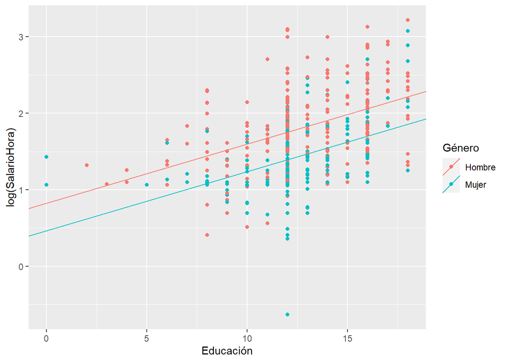

```r
pendientes<- c(coef(modelo1.8)["Educación"],  #Pendiente de hombres
                 coef(modelo1.8)["Educación"] + coef(modelo1.8)["GéneroMujer:Educación"]) #Pendiente de mujeres

rectas.df<- data.frame(interceptos = interceptos,
                       pendientes = pendientes,
                       Género = levels(datos$Género))

qplot(x = Educación, y = log(SalarioHora), color = Género, data = datos) +
  geom_abline(aes(intercept = interceptos,
                  slope = pendientes,
                  color = Género), data = rectas.df)
```

O alternativamente podemos:

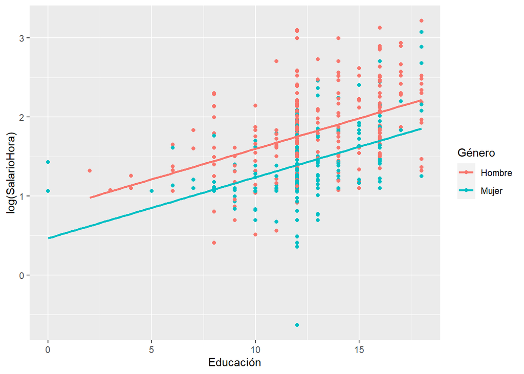

```r
qplot(x = Educación, y = log(SalarioHora) , color = Género, data = datos) +
  stat_smooth(method = "lm", se = FALSE, fullrange = F)
```

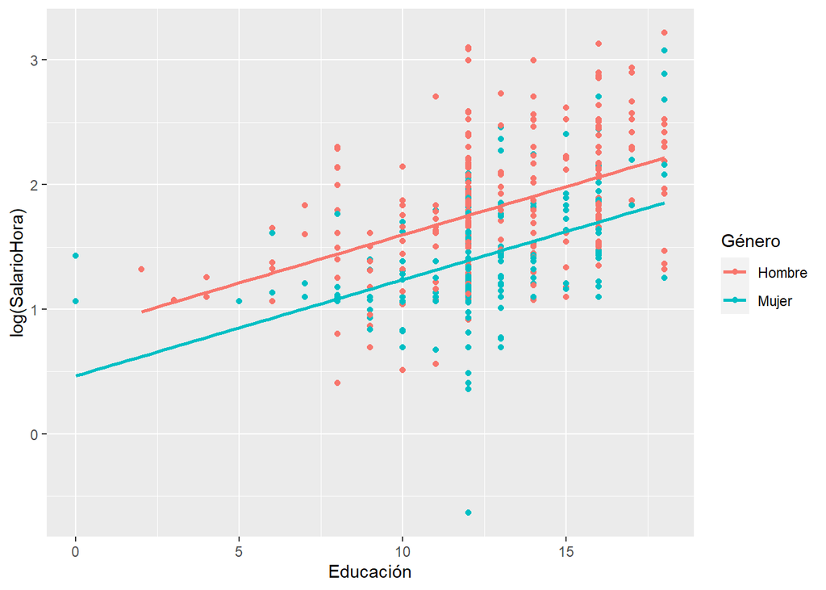

```r
#Otra forma alternativa es
ggplot(datos, aes(x =Educación, y = log(SalarioHora), colour = Género)) + geom_point() +
  stat_smooth(method = "lm", formula = y ~ x, se = FALSE)
```

```r
modelo<-lm(SalarioHora~Género+Educación+ Experiencia+Educación:Experiencia,data = datos)

modelo<-lm(log(SalarioHora)~Género+Educación+Educación:Experiencia+
                Experiencia+I(Experiencia^2)+Antiguedad+I(Antiguedad^2),data = datos)

modelo<-lm(log(SalarioHora)~Educación+Educación:Experiencia+
             Experiencia+I(Experiencia^2),data = datos)

modelo<-lm(log(SalarioHora)~Educación+Educación:Experiencia+
             Experiencia,data = datos)


salida.modelo<- data.frame(xtable(summary(modelo)))
kable(salida.modelo, caption="Ecuación de Salario con interacción y términos cuadráticos")
```

|  | Estimate | Std..Error | t.value | Pr…t.. |
| --- | --- | --- | --- | --- |
| (Intercept) | 0.1532232 | 0.1673326 | 0.9156805 | 0.3602573 |
| Educación | 0.1030365 | 0.0127368 | 8.0896528 | 0.0000000 |
| Experiencia | 0.0132641 | 0.0060374 | 2.1969857 | 0.0284602 |
| Educación:Experiencia | -0.0002473 | 0.0004945 | -0.5000819 | 0.6172282 |

Ploteamos nuestros resultados:

```r
library(jtools)
library(interactions)
```

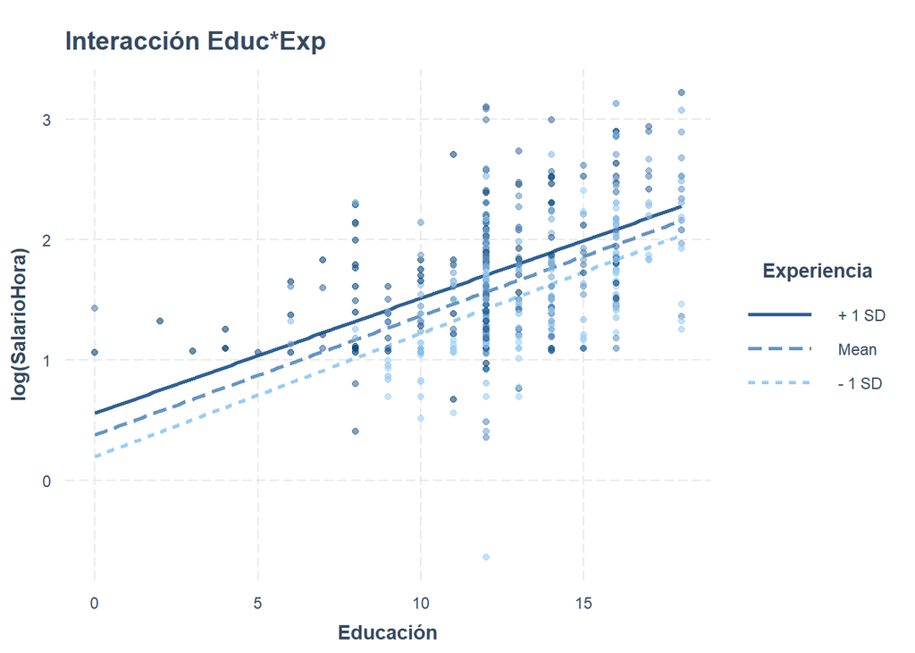

```r
interact_plot(modelo, pred =Educación, modx =Experiencia,
              plot.points = TRUE,main.title="Interacción Educ*Exp",data = datos)
```

Plot sin nube de puntos:

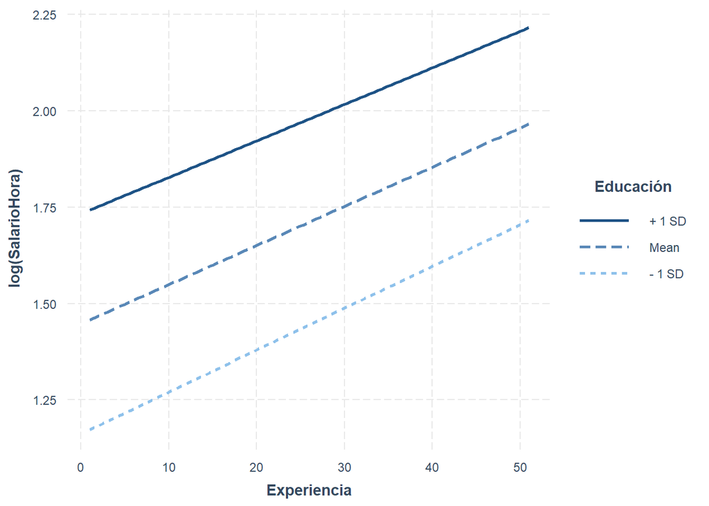

```r
interact_plot(modelo, pred = Experiencia, modx =Educación,plot.points =F,data = datos)
```

Plot con los puntos de datos:

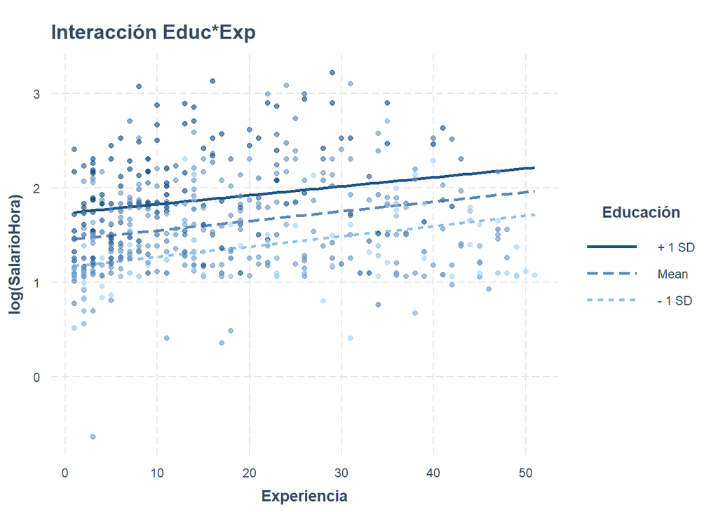

```r
interact_plot(modelo, pred = Experiencia, modx =Educación,
              plot.points = TRUE,main.title="Interacción Educ*Exp",data = datos)
```